# Analyzing TRPA1 orthologs sequences obtained from NCBI

Citing its webpage, "the **National Center for Biotechnology Information (NCBI)** advances science and health by providing access to biomedical and genomic information". It is part of the **National Library of Medicine (NLM)** of the United States, which is a division of the **National Institutes of Health (NIH)**. NCBI contains a wide array of important databases in biotechnology and biomedicine, and it is a key resource in bioinformatics analysis. Some of these databases include:

- **GenBank**: DNA sequences.
- **PubMed**: bibliographic database for biomedical literature.
- **PubChem**: molecules and their activities against biological assays.

**NCBI Datasets** is a new resource that lets you easily gather data from across NCBI databases. With this tool, we can find and download sequences, annotations and metadata of genes, transcripts, protein and genomes. I have prepared this Jupyter notebook to show the capabilities of this resource: the aim of this notebook was to fetch information about TRPA1 orthologs and analyze it with Python.

## 1. Setting up the environment

In this first code cell, some software packages are imported and several helper functions are defined:

```python
import os

import pandas as pd
import matplotlib.pyplot as plt
import ncbi.datasets

from utils import *
```

## 2. Searching for TRPA1 orthologs in NCBI datasets

```python
api_client = ncbi.datasets.ApiClient()
ds_gene_instance = ncbi.datasets.GeneApi(api_client)

# Get gene id by gene symbol + organism name
gene_symbol = 'TRPA1'
gene_taxon = 'human'
gene_descriptor = ds_gene_instance.gene_metadata_by_tax_and_symbol(symbols=[gene_symbol], taxon=gene_taxon)

if not gene_descriptor.genes:
    print(f'No gene found for {gene_taxon} {gene_symbol}')
else:
    gene_id = int(gene_descriptor.genes[0].gene.gene_id)

    # Query the gene ortholog service to get all vertebrate orthologs
    ortholog_set = ds_gene_instance.gene_orthologs_by_id(gene_id=gene_id)
```

## 3. Summary of the data retrieved from NCBI

```python
# extract fields of interest from descriptors class to build a table
cols = '''
common_name
taxonomic_name
symbol
type
chromosome
num_transcripts
ensembl_id
omim_id
uniprot_id
nomenclature_id
nomenclature_auth
genome_coordinates
'''
cols = cols.split('\n')[1:-1]

# specify genes of interest and retrieve descriptors
gene_ids = [int(g.gene.gene_id) for g in ortholog_set.genes.genes]
gene_metadata = ds_gene_instance.gene_metadata_by_id(gene_ids)

# collect elements of the descriptor class into a dictionary based on each gene ID
table_data = {}
for g in gene_metadata.genes:
    if not g.gene:
        print(f'Gene not found: {g}')
        continue
    gene = g.gene

    table_data[gene.gene_id] = [gene.common_name]
    table_data[gene.gene_id].append(gene.taxname)
    table_data[gene.gene_id].append(gene.symbol)
    table_data[gene.gene_id].append(gene.type)
    table_data[gene.gene_id].append(gene.chromosome)
    if gene.transcripts:
        table_data[gene.gene_id].append(len(gene.transcripts))
    else:
        table_data[gene.gene_id].append(0)
    table_data[gene.gene_id].append(gene.ensembl_gene_ids)
    table_data[gene.gene_id].append(gene.omim_ids)
    table_data[gene.gene_id].append(gene.swiss_prot_accessions)
    if gene.nomenclature_authority:
        table_data[gene.gene_id].append(gene.nomenclature_authority.identifier)
        table_data[gene.gene_id].append(gene.nomenclature_authority.authority)
    else:
        table_data[gene.gene_id].append(None)
        table_data[gene.gene_id].append(None)
    table_data[gene.gene_id].append(ranges_repr(gene.genomic_ranges))


df = pd.DataFrame.from_dict(table_data, orient='index', columns=cols)
df.index.name = 'gene_id'
df
```

| gene_id | common_name | taxonomic_name | symbol | type | chromosome | num_transcripts | ensembl_id | omim_id | uniprot_id | nomenclature_id | nomenclature_auth | genome_coordinates |
| --- | --- | --- | --- | --- | --- | --- | --- | --- | --- | --- | --- | --- |
| 100028386 | gray short-tailed opossum | Monodelphis domestica | TRPA1 | PROTEIN_CODING | None | 2 | [ENSMODG00000007215] | None | None | None | None | NC_008803.1:164609682_164679614 |
| 100061564 | horse | Equus caballus | TRPA1 | PROTEIN_CODING | None | 1 | [ENSECAG00000000203] | None | None | VGNC:24548 | VGNC | NC_009152.3:14461430_14513101 |
| 100087634 | platypus | Ornithorhynchus anatinus | TRPA1 | PROTEIN_CODING | None | 1 | [ENSOANG00000013522] | None | None | None | None | NC_041734.1:2151422_2190369 |
| 100152934 | pig | Sus scrofa | TRPA1 | PROTEIN_CODING | None | 3 | [ENSSSCG00000006186] | None | None | VGNC:94459 | VGNC | NC_010446.5:63493374_63558486 |
| 100158526 | tropical clawed frog | Xenopus tropicalis | trpa1 | PROTEIN_CODING | None | 1 | None | None | None | XB-GENE-1004945 | Xenbase | NC_030682.2:120746375_120780978 |
| ... | ... | ... | ... | ... | ... | ... | ... | ... | ... | ... | ... | ... |
| 474353 | zebrafish | Danio rerio | trpa1b | PROTEIN_CODING | None | 3 | [ENSDARG00000031875] | None | None | ZDB-GENE-050106-1 | ZFIN | NC_007135.7:13635005_13714119 |
| 486994 | dog | Canis lupus familiaris | TRPA1 | PROTEIN_CODING | None | 5 | None | None | None | VGNC:47865 | VGNC | NC_051833.1:21050161_21102458,NC_049289.1:2110... |
| 505317 | cattle | Bos taurus | TRPA1 | PROTEIN_CODING | None | 1 | [ENSBTAG00000002062] | None | None | VGNC:36380 | VGNC | NC_037341.1:35611176_35666932 |
| 694623 | Rhesus monkey | Macaca mulatta | TRPA1 | PROTEIN_CODING | None | 1 | [ENSMMUG00000010748] | None | None | VGNC:78429 | VGNC | NC_041761.1:72578580_72632470 |
| 8989 | human | Homo sapiens | TRPA1 | PROTEIN_CODING | None | 4 | [ENSG00000104321] | [604775] | [O75762] | HGNC:497 | HGNC | NC_000008.11:72021250_72094885 |

399 rows × 12 columns

## 4. Retrieving gene, RNA and protein sequences of all TRPA1 orthologs in NCBI

### 4.1. Download

```python
# source = "ncbi_dataset/data/"
# target = "data/"
# for gid in gene_ids:
#     example_usage_of_api([gid])

#     if os.path.exists("ncbi_dataset"):
#         os.system("rm -rf ncbi_dataset")
#     if os.path.exists("README.md"):
#         os.system("rm README.md")
#     os.system(f"unzip gene_ds_{gid}.zip > /dev/null")
#     for fn in ("data_report.jsonl", "gene.fna", "rna.fna", "protein.faa"):
#         os.system(f"mv {source}{fn} {target}{gid}_{fn}")
#     os.system(f"rm gene_ds_{gid}.zip")
print()
```

### 4.2. Load

```python
seqs = {}

for seq_type in ("gene", "rna", "protein"):
    seqs[seq_type] = {}

    fns = [fn for fn in os.listdir("data") if seq_type in fn]

    for fn in fns:
        with open("data/" + fn) as f:
            s = "".join(f.readlines())

        seqs[seq_type][int(fn.split("_")[0])] = read_fasta(s)
```

```python
all_json = ["data/"+fn for fn in os.listdir("data") if fn.endswith("jsonl")]

df = pd.concat([pd.read_json(fn, lines = True) for fn in all_json])
```

## 5. Analysis of the downloaded data

```python
rows = []

for i,r in df.iterrows():
    # transcripts for each gene are embedded as lists and require additional handling
    for transcript in r.transcripts:
        rows.append({
            'gene_id': r.geneId,
            'gene_symbol': r.symbol,
            'gene_taxonomy': r.taxname,
            'accVer': transcript["accessionVersion"],
            'name': transcript.get("name", None),
            'length': transcript["length"],
            '5`UTR_len': five_prime_len(transcript),
            '3`UTR_len': three_prime_len(transcript),
            'protAccVer': transcript.get("protein",{}).get("accessionVersion", None),
            'protName': transcript.get("protein", {}).get("isoformName", None),
            'protLength': transcript.get("protein", {}).get("length", None),
            'exonAccVer': transcript["exons"]["accessionVersion"],
            'numExons': len(transcript["exons"]["range"]),
        })

df = pd.DataFrame(rows)
df[["seqGene", "seqRna", "seqProt"]] = [load_sequences(r) for i,r in df.iterrows()]
df.head()
```

|  | gene_id | gene_symbol | gene_taxonomy | accVer | name | length | 5`UTR_len | 3`UTR_len | protAccVer | protName | protLength | exonAccVer | numExons | seqGene | seqRna | seqProt |
| --- | --- | --- | --- | --- | --- | --- | --- | --- | --- | --- | --- | --- | --- | --- | --- | --- |
| 0 | 111156789 | LOC111156789 | Enhydra lutris kenyoni | XM_022517853.1 | None | 4110 | 0.0 | 0.0 | XP_022373561.1 | None | 1369.0 | NW_019154133.1 | 29 | ATGAGGCGCAGCCTGAGGAAGATGCTGAGCCCTGGGAAGCAGGAGG... | ATGAGGCGCAGCCTGAGGAAGATGCTGAGCCCTGGGAAGCAGGAGG... | MRRSLRKMLSPGKQEEPQGAVYQGVENDMDDSKDSLKVVFEGSTCR... |
| 1 | 110197275 | TRPA1 | Phascolarctos cinereus | XM_020971045.1 | None | 3360 | 0.0 | 0.0 | XP_020826704.1 | None | 1119.0 | NW_018344163.1 | 27 | ATGAAGCGCAATGTGAAGAAAGTACTGCAAGCTCCCGGGGAAAATA... | ATGAAGCGCAATGTGAAGAAAGTACTGCAAGCTCCCGGGGAAAATA... | MKRNVKKVLQAPGENKEPQGVAYEEVENEMDALEDDVFKVIFKGNV... |
| 2 | 116089068 | Trpa1 | Mastomys coucha | XM_031368800.1 | transcript variant X2 | 4171 | 21.0 | 862.0 | XP_031224660.1 | isoform X2 | 1095.0 | NW_022196896.1 | 26 | GCGGGCGTCCAGGTGGAGTCAATGAAGCGCAGCTTGAGGAGGATTC... | GCGGGCGTCCAGGTGGAGTCAATGAAGCGCAGCTTGAGGAGGATTC... | MKRSLRRILRPEERKEVQGVVYRGVGEDMACSKESFKVDIEGDVCR... |
| 3 | 116089068 | Trpa1 | Mastomys coucha | XM_031368799.1 | transcript variant X1 | 4261 | 21.0 | 862.0 | XP_031224659.1 | isoform X1 | 1125.0 | NW_022196896.1 | 27 | GCGGGCGTCCAGGTGGAGTCAATGAAGCGCAGCTTGAGGAGGATTC... | GCGGGCGTCCAGGTGGAGTCAATGAAGCGCAGCTTGAGGAGGATTC... | MKRSLRRILRPEERKEVQGVVYRGVGEDMACSKESFKVDIEGDVCR... |
| 4 | 108935409 | trpa1b | Scleropages formosus | XM_029255039.1 | None | 3375 | 0.0 | 0.0 | XP_029110872.1 | None | 1124.0 | NC_041814.1 | 27 | ATGCATTATACCAAGGAGCATACGAAGCAGAACAATTTCTACAAAT... | ATGCATTATACCAAGGAGCATACGAAGCAGAACAATTTCTACAAAT... | MHYTKEHTKQNNFYKCVIDEEETALASANVFEEALHGNAALLESLS... |

### 5.1. Distribution of numerical columns

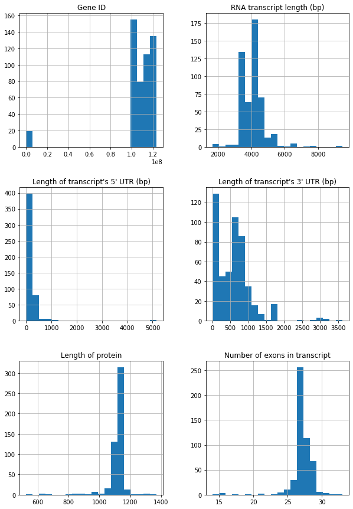

```python
ax = df.hist(figsize = (10,15), bins = 20)

ax[0,0].set_title("Gene ID")
ax[0,1].set_title("RNA transcript length (bp)")
ax[1,0].set_title("Length of transcript's 5' UTR (bp)")
ax[1,1].set_title("Length of transcript's 3' UTR (bp)")
ax[2,0].set_title("Length of protein")
ax[2,1].set_title("Number of exons in transcript")
plt.show()
```

### 5.2. GC content

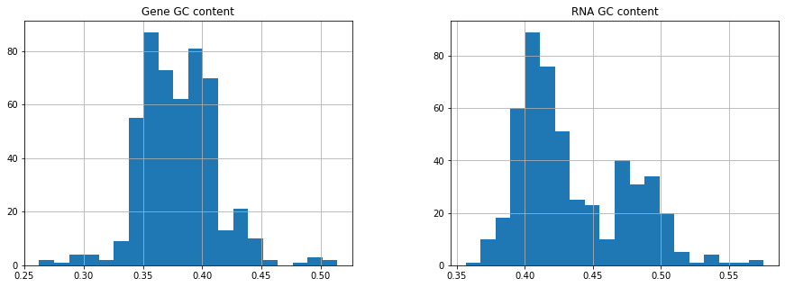

```python
df[["geneGC","rnaGC"]] = [[gc_content(r, "seqGene"),gc_content(r, "seqRna")]
                          for i,r in df.iterrows()]

ax = df[["geneGC","rnaGC"]].hist(figsize=(15,5), bins = 20)
ax[0,0].set_title("Gene GC content")
ax[0,1].set_title("RNA GC content")
plt.show()
```

### 5.3. Proportion of polar amino acids in protein

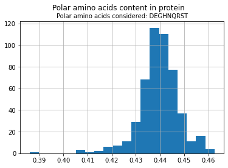

|  | gene_id | gene_symbol | gene_taxonomy | accVer | name | length | 5`UTR_len | 3`UTR_len | protAccVer | protName | protLength | exonAccVer | numExons | seqGene | seqRna | seqProt | geneGC | rnaGC | polarAminoAcids |
| --- | --- | --- | --- | --- | --- | --- | --- | --- | --- | --- | --- | --- | --- | --- | --- | --- | --- | --- | --- |
| 465 | 100545876 | TRPA1 | Meleagris gallopavo | XM_019614085.2 | None | 1666 | 78.0 | 7.0 | XP_019469630.1 | None | 526.0 | NC_015013.2 | 14 | TTATATCTTCTATATGTAAGTGACTATAAAGGCTGGACAGCCCTGC... | TTATATCTTCTATATGTAAGTGACTATAAAGGCTGGACAGCCCTGC... | MQIILDTNVKCTDKVDEEGNTALHLAAKEGHAKAVRLLLDYGAKIL... | 0.330620 | 0.388956 | 0.385932 |
| 48 | 104557790 | TRPA1 | Colius striatus | XM_010202140.1 | None | 1981 | 1.0 | 0.0 | XP_010200442.1 | None | 660.0 | NW_010692615.1 | 17 | GACAGCATTGTTTGATCATTACGAACTGGCCGAGTATTTGATTTCA... | GACAGCATTGTTTGATCATTACGAACTGGCCGAGTATTTGATTTCA... | TALFDHYELAEYLISMGANIDSVDIEGRSPLLLATSCASWKIVNLL... | 0.355168 | 0.405856 | 0.406061 |
| 293 | 104073844 | TRPA1 | Fulmarus glacialis | XM_009573770.1 | None | 2073 | 1.0 | 194.0 | XP_009572065.1 | None | 625.0 | NW_009200975.1 | 15 | TTTTCCATTTATAATTACTAATTTTATACCACTACATGTAAGTGAT... | TTTTCCATTTATAATTACTAATTTTATACCACTACATGTAAGTGAT... | FPFIITNFIPLHVSDYKGWTALHHAAFGGYTRTMQIILDTNVKCTD... | 0.345803 | 0.384467 | 0.406400 |
| 425 | 104399637 | TRPA1 | Nestor notabilis | XM_010013589.1 | None | 2036 | 1.0 | 199.0 | XP_010011891.1 | None | 611.0 | NW_009926571.1 | 15 | TGATTATAAAGGCTGGACAGCCCTGCATCATGCTGCCTTTGGAGGA... | TGATTATAAAGGCTGGACAGCCCTGCATCATGCTGCCTTTGGAGGA... | DYKGWTALHHAAFGGYTRTMQIILDTNVKCTDRVDEEGNTALHLAA... | 0.340448 | 0.386542 | 0.407529 |
| 164 | 118090239 | TRPA1 | Zootoca vivipara | XM_035125683.1 | transcript variant X2 | 6361 | 228.0 | 3037.0 | XP_034981574.1 | isoform X2 | 1031.0 | NC_048612.1 | 27 | TCAAGCAGCACTCCCCTACTGAATTATATGTAAGGAACAGCAGATG... | ACTACGAAGTTTCATTAAGAAGAATCGGGATGGTCTTAAGAAACTG... | MKLNVGRLMTALNVTDSCGNTPLHWATKKSQIGSVKLLLRKGANPN... | 0.409122 | 0.393492 | 0.412221 |
| ... | ... | ... | ... | ... | ... | ... | ... | ... | ... | ... | ... | ... | ... | ... | ... | ... | ... | ... | ... |
| 352 | 102759207 | TRPA1 | Myotis davidii | XM_006767358.2 | None | 3886 | 0.0 | 529.0 | XP_006767421.1 | None | 1118.0 | NW_006293700.1 | 27 | ATGAGGCGCAACCTGAGGAGGATGCTGCGCACGGGGGGGAAGAAGG... | ATGAGGCGCAACCTGAGGAGGATGCTGCGCACGGGGGGGAAGAAGG... | MRRNLRRMLRTGGKKEPQGVVYQGVEDDMDDSKDSFKVVFEGNANE... | 0.405268 | 0.448019 | 0.462433 |
| 390 | 118912815 | TRPA1 | Manis pentadactyla | XM_036886289.1 | transcript variant X4 | 4184 | 289.0 | 643.0 | XP_036742184.1 | isoform X3 | 1083.0 | NW_023457987.1 | 28 | GGTGCGCGCCGCTCCACCTGCAGCCGGCTCAGCAGGCCGAGCCTTC... | GGTGCGCGCCGCTCCACCTGCAGCCGGCTCAGCAGGCCGAGCCTTC... | MKRSLRRMLRPGEKEPQSAVYQGVGDDMDDSRDSLKVVFEGSECKL... | 0.331434 | 0.431883 | 0.462604 |
| 119 | 107515189 | TRPA1 | Rousettus aegyptiacus | XR_004954578.1 | transcript variant X3 | 3344 | NaN | NaN | None | None | NaN | NW_023416290.1 | 25 | CGCACCCCCGCCGCCCACCGCGCCCCTCCTCTCTCCTGCGCTACAA... | GCACCCCCGCCGCCCACCGCGCCCCTCCTCTCTCCTGCGCTACAAG... |  | 0.432060 | 0.492823 | NaN |
| 359 | 106839196 | TRPA1 | Equus asinus | XR_006526288.1 | transcript variant X4 | 3646 | NaN | NaN | None | None | NaN | NC_052179.1 | 27 | GGAGAGCAGAGGCCTTCCACTCCACGCATCACACCTGTGCCGGTGA... | GCGCTGCTGCAGCGCAGACAGGCAAGTCGTGCTTCCCCCCGGATCC... |  | 0.399541 | 0.470927 | NaN |
| 360 | 106839196 | TRPA1 | Equus asinus | XR_006526289.1 | transcript variant X5 | 3607 | NaN | NaN | None | None | NaN | NC_052179.1 | 26 | GGAGAGCAGAGGCCTTCCACTCCACGCATCACACCTGTGCCGGTGA... | GCGCTGCTGCAGCGCAGACAGGCAAGTCGTGCTTCCCCCCGGATCC... |  | 0.399541 | 0.466315 | NaN |

502 rows × 19 columns

```python
polar_aa = "DEGHNQRST"

df["polarAminoAcids"] = [count_polar(r, polar_aa) for i,r in df.iterrows()]
df.polarAminoAcids.hist(bins = 20)
plt.suptitle("Polar amino acids content in protein")
plt.title("Polar amino acids considered: "+polar_aa, fontsize = 10)
plt.show()

df.sort_values("polarAminoAcids")
```

### 5.4. Relationships between gene and RNA GC content and protein polarity

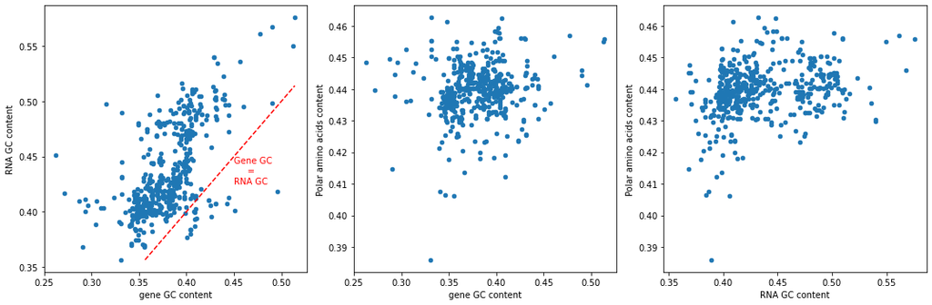

```python
fig,ax = plt.subplots(1,3, figsize = (15,5))

df.plot.scatter(x = "geneGC", y = "rnaGC",
                xlabel = "gene GC content",
                ylabel = "RNA GC content", ax = ax[0])
ax[0].plot([df.rnaGC.min(),df.geneGC.max()],
           [df.rnaGC.min(),df.geneGC.max()],
           "r", linestyle="--")
ax[0].text(0.45,0.45, "Gene GC\n     =\nRNA GC", va = "top", color = "r")
df.plot.scatter(x = "geneGC", y = "polarAminoAcids",
                xlabel = "gene GC content",
                ylabel = "Polar amino acids content",
                ax = ax[1])
df.plot.scatter(x = "rnaGC", y = "polarAminoAcids",
                xlabel = "RNA GC content",
                ylabel = "Polar amino acids content",
                ax = ax[2])

plt.tight_layout()
plt.show()
```